# Analysis

2024-05-14

# Species

(I actually don’t think we need a figure of this but I was trying something out)

Overview of the species in focus

| species | n |
| --- | --- |
| pigs | 25 |
| poultry | 25 |
| cattle | 23 |
| horses | 14 |
| goats | 12 |
| sheep | 12 |
| rabbits | 10 |
| birds | 8 |
| fish | 8 |
| cows | 7 |
| mammals | 7 |
| boars | 5 |
| bovine | 4 |
| cats | 4 |
| dogs | 4 |
| ruminants | 4 |
| salmon | 4 |
| bees | 3 |
| geese | 3 |
| ungulates | 3 |
| deer | 2 |
| ducks | 2 |
| quails | 2 |
| reptiles | 2 |
| all | 1 |
| amphibians | 1 |
| arachnids | 1 |
| bats | 1 |
| beetle | 1 |
| camels | 1 |
| crustaceans | 1 |
| insects | 1 |
| mink | 1 |
| molluscs | 1 |
| ovine | 1 |
| oysters | 1 |
| primates | 1 |
| seals | 1 |
| turbot | 1 |
| wild birds | 1 |
| wild boar | 1 |
| wild ruminants | 1 |
| NA | 1 |

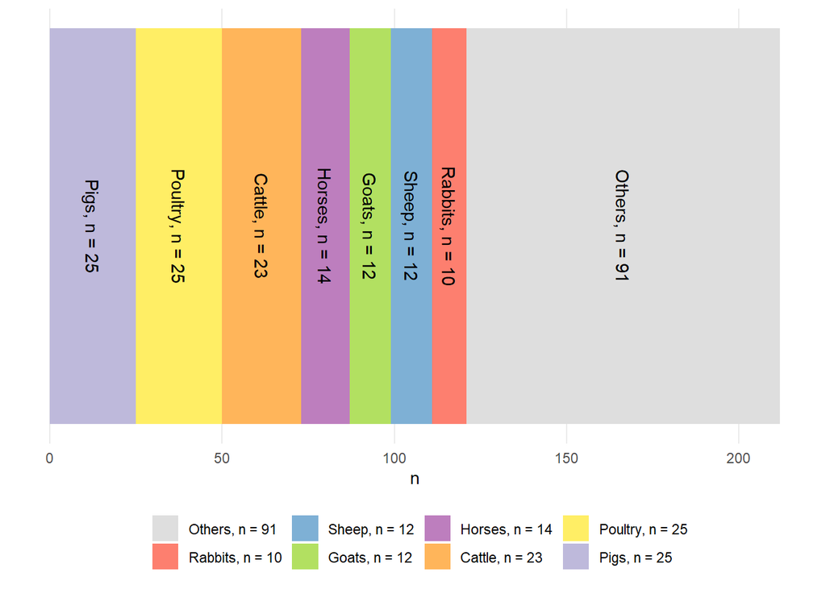

# Scope of the study

Overview of the types of SR items extracted

| Scope | Subscope | n_per_subscope |
| --- | --- | --- |
| disease | methodology, test | 2 |
| disease | vaccine | 2 |
| disease | NA | 86 |
| distribution | NA | 1 |
| methodology | NA | 1 |
| risk assessment | husbandry? | 1 |
| safety | NA | 1 |
| welfare | husbandry, transport, breeding | 33 |
| welfare | killing | 20 |
| welfare | testing | 1 |
| welfare | NA | 1 |
| welfare & disease | NA | 1 |
| welfare & safety | husbandry, transport, breeding | 1 |

Overview of the scope of each report

| Scope | n_per_scope |
| --- | --- |
| disease | 90 |
| distribution | 1 |
| methodology | 1 |
| risk assessment | 1 |
| safety | 1 |
| welfare | 55 |
| welfare & disease | 1 |
| welfare & safety | 1 |

# Type of study

Important throughout: within one report more than one study can be found.

Overview of the study types

| name | n_per_studytype |
| --- | --- |
| AHL | 42 |
| Database | 16 |
| Literature review | 126 |
| Observational | 5 |
| Primary study | 1 |
| Systematic review | 40 |
| Survey | 23 |

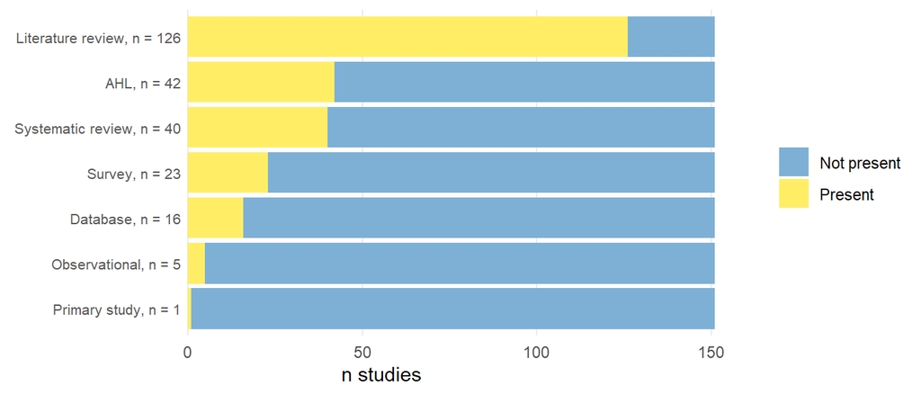

### Graphical overview of the studies extracted over the years

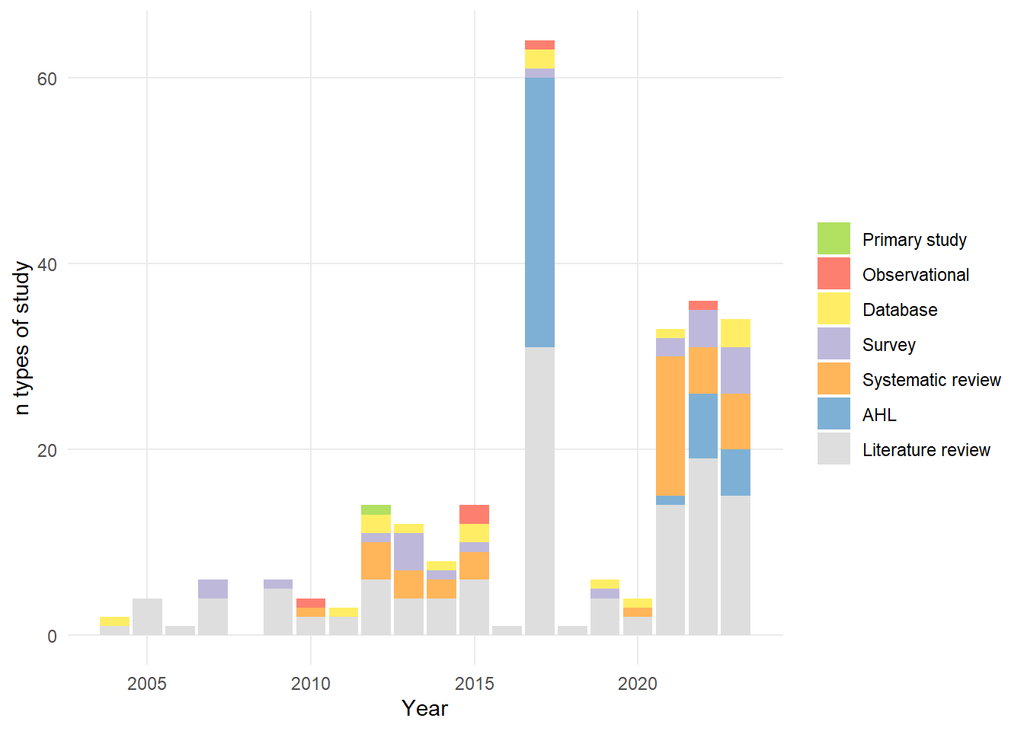

# Systematic Reviews items

Important: even if a systematic review wasn’t recorded because it didn’t fit our inclusion criteria, we recorded each item independently (for instance: in a report a systematic review was conducted, a flowchart reported, involving two reviewers, but only 1 database was searched. This wouldn’t categorize as SR, but the item flowchart and reviewers were recorded)

Overview of the types of SR items extracted

| Study type | n |
| --- | --- |
| Search string | 54 |
| Databases | 48 |
| Flowchart | 28 |
| Label_els | 25 |
| Reviewers | 21 |
| Label_sr | 11 |
| Rob | 8 |
| Protocol | 4 |
| Meta-analysis | 2 |
| Label_lr | 1 |
| Total reports | 151 |

Search string: search string was present. Databases: 2 or more databases were searched. Flowchart: a flowchart was present. Reviewers: two or more reviewers screened the literature. Protocol: a a-priori protocol was written and published. Rob: a risk of bias analysis was performed. Meta-analysis: a meta-analysis was performed.

### SR items extracted over the years

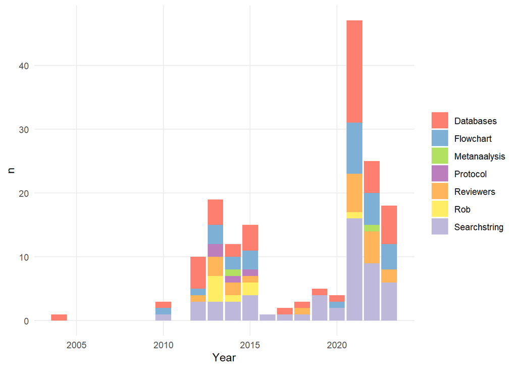

### SR items extracted over the years

Top part of the figure: studies extracted and proportion of SRs (dark gray) of the total studies extracted per year (light gray). Lower part of the figure: proportion of the various items of SRs extracted. The idea was to display everything in one figure **but** it has the problem of the y-scale. The number of studies has a straightforward scale, but if the raw numbers are diplayed in the lower part of the graph, it would not match the upper part. So this is still a work-in-progress

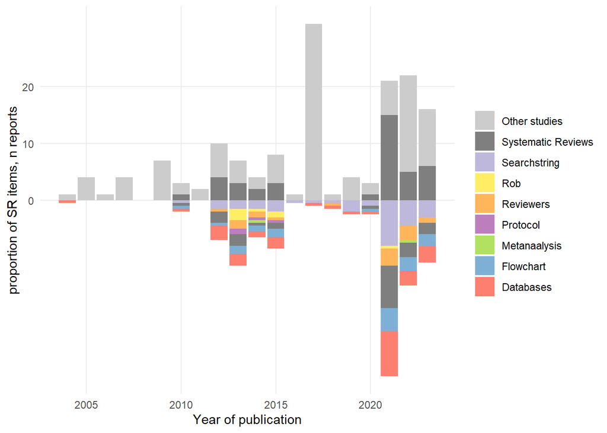

### Databases used

The number database used ranged from 1 to 15, with a median of 2

### Classification of reviews

25 reviews were classified as ELS (extensive literature reviews). 11 reviews were classified as systematic reviews.4 were classified as neither, but were annotated by us as SR.

Even though only 40 SRs were extracted according to our a-priori criteria, various items of a systematic review were extracted from 63 studies.